# BIOS 534 Homework 3

Initial Release 04/07/26

**30 Points (see individual sections for specific point values)**

- Due by **11:59 PM (Canvas Clock Time)** on **April 20, 2026**
- Read problem descriptions carefully
- Send questions to the TA
- IMPORTANT Start sooner rather than later. Please submit your work on time to expedite grading.

## Submission Instructions

- Use **Jupyter / JupyterLab** for all work.
- SUBMIT BOTH of the following files via Emory Canvas:
  1. Your Jupyter Notebook (.ipynb) containing all code and results
  2. An HTML export of the notebook (see below on how to create)
- For questions in Section 1, type your responses directly into a Markdown cell.
- Clearly label each response with the corresponding question number (for example, “Question 1.1”) before writing your answer.

## Creating the HTML Export

In Jupyter or JupyterLab:

**File -> Save and Export Notebook As -> HTML**

The HTML file allows the teaching team to quickly review your work without relying on local software configurations, while the `.ipynb` file allows us to run your code if needed.

Your notebook must contain **runnable code** for questions that require code. If your code does not run, we cannot grade it.

## Academic Honesty Policy

- All work must be **your own**.
- **Do not share, accept, or co-develop code** for any problems.
- **AI tools (ChatGPT, CoPilot)** and external sources, including **current or former students**, are **not permitted**.

## Biomarker Classification Dataset

This assignment uses a biomarker dataset containing subjects labeled as **Control** or **Impaired**, with the goal of predicting diagnosis using machine learning classification methods in scikit-learn. The dataset consists of numerical biomarker measurements collected across a range of physiological systems, including markers associated with inflammation, vascular signaling, metabolism, and neurodegeneration.

Several predictors are of particular interest in Alzheimer’s disease research, including **tau**, **p_tau**, and **Ab_42**, which are widely studied because of their relationship to neuronal injury, tau pathology, and amyloid accumulation. Other biomarkers in the dataset may reflect inflammatory or systemic biological processes that also contribute to disease-related variation.

Because the number of **Control** subjects exceeds the number of **Impaired** subjects, the dataset is moderately imbalanced. As a result, a classification model may achieve reasonable overall accuracy while still performing poorly when identifying the minority class. For that reason, model evaluation should include not only accuracy, but also sensitivity, specificity, and precision so that minority-class performance is interpreted carefully. Here is the data

```python
import pandas as pd

url = "https://raw.githubusercontent.com/steviep42/bios_534/refs/heads/main/data/alz_selected_20_features.csv"
alz = pd.read_csv(url)

# Take a look
alz.head()

# rows and columns
print("Shape:", alz.shape,"\n")

# How many Impaired cases vs Control (non-impaired)
print(alz['diagnosis'].value_counts())
```

```
Shape: (333, 21)

diagnosis
Control     242
Impaired     91
Name: count, dtype: int64
```

|  | Eotaxin_3 | FAS | Fibrinogen | GRO_alpha | Gamma_Interferon_induced_Monokin | IGF_BP_2 | MIF | MMP10 | MMP7 | NT_proBNP | PAI_1 | Pancreatic_polypeptide | Resistin | TNF_RII | TRAIL_R3 | Thymus_Expressed_Chemokine_TECK | age | tau | p_tau | Ab_42 | diagnosis |
| --- | --- | --- | --- | --- | --- | --- | --- | --- | --- | --- | --- | --- | --- | --- | --- | --- | --- | --- | --- | --- | --- |
| 0 | 53 | -0.0833816 | -7.03559 | 1.38183 | 2.94982 | 5.60947 | -1.23787 | -3.27017 | -3.7735 | 4.55388 | 1.0035 | 0.578781 | -16.4753 | -0.0618754 | -0.1829 | 4.14933 | 0.987624 | 6.29775 | 4.34811 | 12.0197 | Control |
| 1 | 62 | -0.527633 | -8.04719 | 1.37244 | 2.72179 | 5.34711 | -1.89712 | -3.64966 | -5.96819 | 4.21951 | -0.0305988 | 0.336472 | -16.0253 | -0.328504 | -0.500747 | 3.81018 | 0.98615 | 6.65929 | 4.85997 | 11.0158 | Control |
| 2 | 62 | -0.634878 | -7.19544 | 1.41268 | 2.76223 | 5.18178 | -2.30259 | -2.73337 | -4.03023 | 4.2485 | 0.438372 | -0.891598 | -16.4753 | -0.415515 | -0.924034 | 2.79199 | 0.986667 | 6.27099 | 4.40025 | 12.3023 | Control |
| 3 | 44 | -0.478036 | -7.79935 | 1.37244 | 2.88548 | 5.42495 | -1.66073 | -4.07454 | -6.85615 | 4.11087 | -0 | -0.820981 | -13.5012 | -0.34249 | -0.384859 | 4.03728 | 0.986702 | 6.15273 | 4.49489 | 12.3981 | Control |
| 4 | 64 | -0.127833 | -6.98033 | 1.39843 | 2.85199 | 5.42053 | -1.89712 | -2.6173 | -0.222222 | 4.46591 | 0.252305 | 0.262364 | -11.0928 | -0.34249 | -0.858259 | 4.53416 | 0.987163 | 6.62371 | 4.52459 | 11.0241 | Control |

## Q1 - Exploring Correlated Biomarkers

**1.1)** (2.5 pts) Before fitting classification models, examine correlations among the predictors in the dataset. Compute a correlation matrix using all numeric predictor columns (excluding `diagnosis`) and generate a plot showing only variable pairs with **absolute** correlation greater than **0.65**.

Check the Classification notebook and the Seaborn page for the Heatmap function for information. It’s also easy to filter on values > than absolute value of **0.65**.

**1.2)** (2.5 pts) Identify any biomarker pairs that appear strongly correlated and comment on why correlated predictors may matter in later model interpretation. Your correlation matrix graphic need not match the following output exactly although the computed correlations should match.

Consult the course notebooks on how to construct the correlation matrix and associated heatmap.

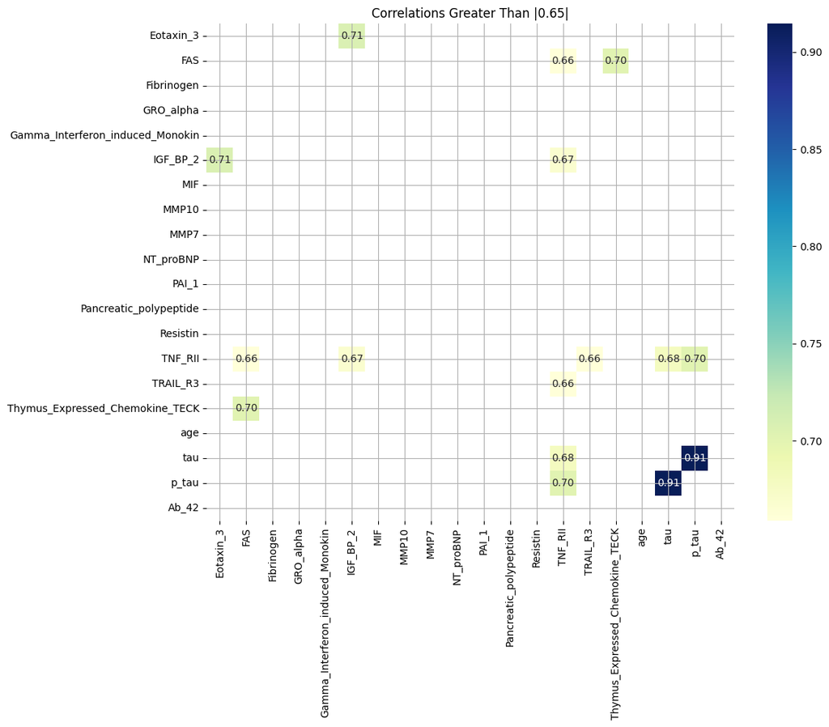

## Q2 - Logistic Regression Using the Full Predictor Set

**2.1)** (0.5 points) Convert diagnosis so that Control maps to 0 and Impaired maps to 1

**2.2)** (0.5 points) Split the data into training and testing sets using an 80/20 split - 2.2.1 Use `randmod_state=42`. - 2.2.2 Use `stratify=y`.

**2.3)** (1 point) Fit a logistic regression model using a pipeline. Use `make_pipeline(StandardScaler(), LogisticRegression(max_iter=5000))` with the full biomarker dataset, treating `diagnosis` as the response variable and all remaining columns as predictors.

**2.4)** (1 point) After fitting the model, generate predictions on the **test set** and use scikit functions to generate the following.

- 2.4.1 confusion matrix
- 2.4.2 accuracy
- 2.4.3 sensitivity
- 2.4.4 specificity
- 2.4.5 precision

**2.5)** (2 points) Comment on whether accuracy alone adequately describes model performance. Do **NOT** compute these metrics by hand - use scikit functions only.

```
Confusion Matrix:
[[46  3]
 [ 5 13]]

Accuracy: 0.881
Sensitivity: 0.722
Specificity: 0.939
Precision: 0.812
```

## Q3 - Balanced Logistic Regression

**3.1)** (2.5 points) Refit the logistic regression estimator using the same pipeline as in Question #2 except implements a `LogisticRegression(max_iter=5000, class_weight='balanced')` estimator.

**3.2)** (2.5 points) Compute the same evaluation metrics as before and compare this Logistic Regression Balanced model to the original Logistic Regression model in Question 2. Explain why class weighting might change model behavior in an imbalanced dataset.

```
Balanced Logistic Regression
Confusion Matrix:
[[39 10]
 [ 2 16]]

Accuracy: 0.821
Sensitivity: 0.889
Specificity: 0.796
Precision: 0.615
```

## Q4 - Coefficient Interpretation

**4.1)** (1 point) Extract the coefficients from the balanced logistic regression model in Q3 and print them from smallest to largest.

**4.2)** (1 point) Using the absolute values, identify the three predictors with the largest magnitudes and the three with the smallest magnitudes.

**4.3)** (1 point) Explain how coefficient magnitude can be used to guide feature selection when building a reduced model.

**4.4)** (2 points) Comment on why biologically related predictors such as **tau** and **p_tau** may not necessarily have coefficients with similar values or signs when included in the same model.

```
All coefficients (sorted):
TNF_RII                            -1.158362
Ab_42                              -0.870339
p_tau                              -0.696452
age                                -0.433794
MIF                                -0.228948
IGF_BP_2                           -0.112660
Resistin                           -0.067910
MMP10                              -0.005805
Fibrinogen                         -0.002406
Thymus_Expressed_Chemokine_TECK     0.117841
MMP7                                0.129871
GRO_alpha                           0.211420
Eotaxin_3                           0.286294
PAI_1                               0.322769
FAS                                 0.408506
Pancreatic_polypeptide              0.439699
Gamma_Interferon_induced_Monokin    0.440473
TRAIL_R3                            0.457481
NT_proBNP                           0.529939
tau                                 1.692443
dtype: float64

Top 3 predictors by absolute magnitude:
tau        1.692443
TNF_RII    1.158362
Ab_42      0.870339
dtype: float64

Bottom 3 predictors by absolute magnitude:
Resistin      0.067910
MMP10         0.005805
Fibrinogen    0.002406
dtype: float64
```

## Q5 - Feature Selection and Logistic Regression

**5.1)** (1 points) Use `SelectKBest(score_func=f_classif, k="all")` to score all predictors. Make sure to use the **training** data from Question 2.

**5.2)** (0.5 point) Print the predictors ranked from strongest to weakest based on their scores, and identify the top three predictors.

**5.3)** (1.5 points) Fit a **balanced logistic regression** model using the pipeline from Question 3. Use only the top 3 predictors identified in 5.2. Generate predictions on the test set and compute the confusion matrix, accuracy, sensitivity, specificity, and precision.

**5.4)** (2 points) Compare these results to the earlier balanced logistic regression model using all predictors (Question 3). What does this suggest about whether a smaller subset of predictors can preserve or improve classification performance?

```
Predictors ranked by f_classif score:
tau                                 59.841648
Ab_42                               42.857782
p_tau                               33.454880
GRO_alpha                           27.540198
NT_proBNP                           24.195066
MMP10                               22.430877
TRAIL_R3                            21.369251
Pancreatic_polypeptide              20.138457
FAS                                 19.515765
MIF                                 17.803136
PAI_1                               16.610235
MMP7                                12.428135
Eotaxin_3                           12.182655
IGF_BP_2                            11.815916
Gamma_Interferon_induced_Monokin    11.735478
Resistin                            11.261767
TNF_RII                             10.682065
Fibrinogen                          10.653519
Thymus_Expressed_Chemokine_TECK      9.846045
age                                  9.148141
dtype: float64

Top 3 predictors:
tau      59.841648
Ab_42    42.857782
p_tau    33.454880
dtype: float64

Confusion Matrix:
[[40  9]
 [ 4 14]]

Accuracy: 0.806
Sensitivity (Recall): 0.778
Specificity: 0.816
Precision: 0.609
```

## Q6 - Random Forest and Variable Importance

**6.1)** (1 points) Using the Train / Test split from Question 2, fit a `RandomForestClassifier(random_state=42, class_weight="balanced")` estimator using the full biomarker set and extract variable importance values.

**6.2)** (0.5 points) Print the predictors from most important to least important (in terms of score magnitude).

**6.3)** (0.5 points) Fit a second `RandomForestClassifier(random_state=42, class_weight="balanced")` estimator using the top **10** variables.

**6.4)** (1 point) For the **test data**, make predictions and compute the confusion matrix, accuracy, sensitivity, specificity, and precision, and compare these results to the **balanced logistic regression model test results** in Question 3.

**6.5)** (2 points) Compare the performance to the results of Question 5

```
Random Forest variable importance:
Ab_42                               0.155699
tau                                 0.132806
MMP10                               0.055509
p_tau                               0.054997
NT_proBNP                           0.051834
Pancreatic_polypeptide              0.048747
MMP7                                0.042068
Eotaxin_3                           0.041090
GRO_alpha                           0.039931
FAS                                 0.039372
Fibrinogen                          0.038447
age                                 0.037481
Gamma_Interferon_induced_Monokin    0.036680
PAI_1                               0.036150
Resistin                            0.034284
IGF_BP_2                            0.032832
TRAIL_R3                            0.031410
TNF_RII                             0.031305
MIF                                 0.031076
Thymus_Expressed_Chemokine_TECK     0.028280
dtype: float64

Top 10 predictors:
Ab_42                     0.155699
tau                       0.132806
MMP10                     0.055509
p_tau                     0.054997
NT_proBNP                 0.051834
Pancreatic_polypeptide    0.048747
MMP7                      0.042068
Eotaxin_3                 0.041090
GRO_alpha                 0.039931
FAS                       0.039372
dtype: float64

Confusion Matrix:
[[44  5]
 [ 5 13]]

Accuracy: 0.851
Sensitivity: 0.722
Specificity: 0.898
Precision: 0.722
```